# 4_results_main_auxiliary

## Figure 1

The figure below is made using Logistic Regression and corresponds to the figure in the paper.

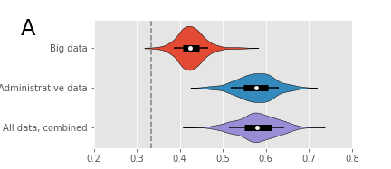

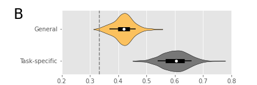

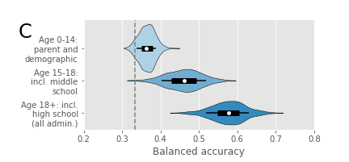

```python
from IPython.display import Image, display
display(Image('output/major_lr_p1_letter.png'))
display(Image('output/task_lr_p1_letter.png'))
display(Image('output/expanding_lr_p1_letter.png'))
```

#### Distribution of hyperparameters for logistic regression model

From an inspection of the hyperparameters below we see that the model based on big data usually is sparse and tends to select a single feature. For administrative and the combined data, usually more features are selected.

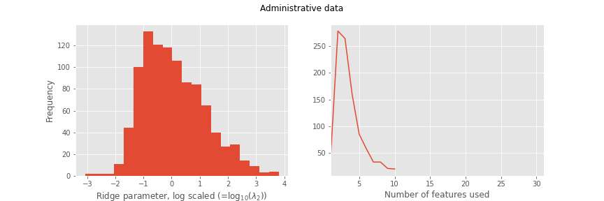

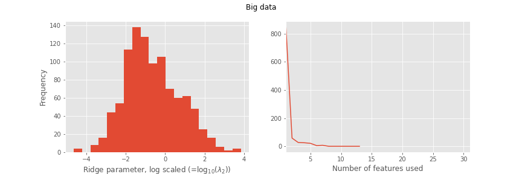

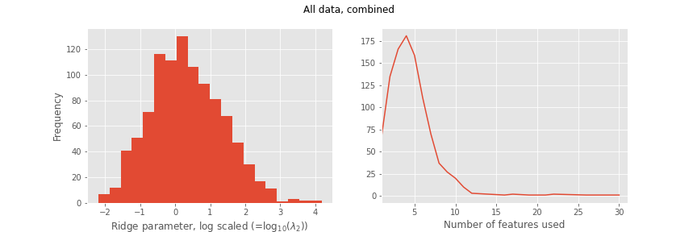

```python
display(Image('output/lr_hyperparams_pre_all.png'))
display(Image('output/lr_hyperparams_post_all.png'))
display(Image('output/lr_hyperparams_combined_all.png'))
```

## Alternative classifiers

In addition to logistic regression we also estimate different models and compare the predictive performane. Below we extract we show the results for random forest with fixed and tuned hyperparameters. The fixed hyperparameters correspond to different values of the tuned hyperparameters.

#### Using Random Forest with fixed hyperparameters (max_depth=20, min_sample_split=5)

The figure below is as the main figure but estimated using the random forest classifier under fixed hyperparameters. The performance under these alternative specifications is found in the data.

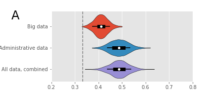

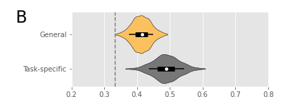

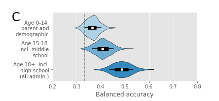

```python
display(Image('output/major_rf_nt_20md_5mss_letter.png'))
display(Image('output/task_rf_nt_20md_5mss_letter.png'))
display(Image('output/expanding_rf_nt_20md_5mss_letter.png'))
```

#### Using Random Forest with estimated hyperparameters

The figure below is as the main figure but estimated using the random forest classifier with tuned hyperparameters. The performance of the random forest classifier with feature selection is also found in the data.

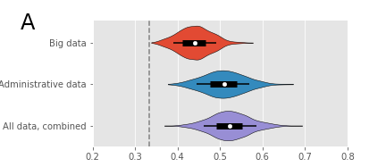

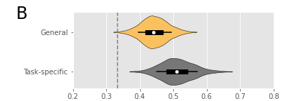

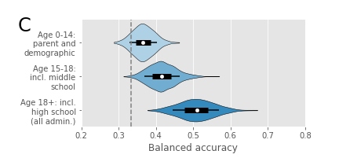

```python
display(Image('output/major_rf_t_nfs_letter.png'))
display(Image('output/task_rf_t_nfs_letter.png'))
display(Image('output/expanding_rf_t_nfs_letter.png'))
```

#### Logistic regression with polynomial interaction of feature

Below we show the performance where all features are interacted before the logistic regression model pipeline is estimated and evaluated.

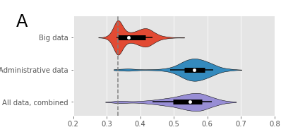

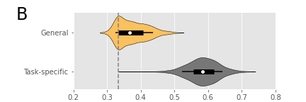

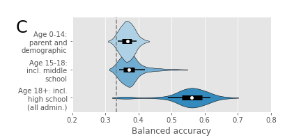

```python
from IPython.display import Image, display
display(Image('output/major_lr_p2_letter.png'))
display(Image('output/task_lr_p2_letter.png'))
display(Image('output/expanding_lr_p2_letter.png'))
```

#### Statistical tests for comparison under different models

The table below replicate the statistical tests, including using alternative classifiers.

```python
import pandas as pd
pd.read_csv('output/comparison_tab_classifiers.csv',index_col=0,header=[0])
```

|  | Logistic Regression, polynom. order=1 | Logistic Regression, polynom. order=2 | Random forest, fixed hyperparam. (max_depth,20; min_sample_split,5) | Random forest, w/o feat. select. |
| --- | --- | --- | --- | --- |
| Administrative data vs Big data | -0.15 (p=0.0000) | -0.18 (p=0.0001) | -0.08 (p=0.0064) | -0.07 (p=0.0508) |
| Administrative data vs All data, combined | 0.00 (p=0.9104) | -0.02 (p=0.7346) | 0.00 (p=0.9637) | 0.01 (p=0.6738) |
| Age 0-14: parent and demographic vs Age 15-18: incl. middle school | 0.10 (p=0.0005) | 0.01 (p=0.5524) | 0.04 (p=0.0355) | 0.05 (p=0.0389) |
| Age 15-18: incl. middle school vs Administrative data | 0.12 (p=0.0005) | 0.18 (p=0.0000) | 0.08 (p=0.0014) | 0.09 (p=0.0044) |
| General vs Task-specific | 0.18 (p=0.0000) | 0.21 (p=0.0000) | 0.08 (p=0.0058) | 0.07 (p=0.0462) |

#### Comparison of balanced accuracy under different models

```python
pd.read_csv('output/acc_tab_classifiers.csv',index_col=0,header=[0,1])
```

| Model Feature set | Logistic Regression, polynom. order=1 Mean | Logistic Regression, polynom. order=1 Std. Dev. | Logistic Regression, polynom. order=2 Mean | Logistic Regression, polynom. order=2 Std. Dev. | Random forest, fixed hyperparam. (max_depth,20; min_sample_split,5) Mean | Random forest, fixed hyperparam. (max_depth,20; min_sample_split,5) Std. Dev. | Random forest, w/o feat. select. Mean | Random forest, w/o feat. select. Std. Dev. |
| --- | --- | --- | --- | --- | --- | --- | --- | --- |
| Big data | 0.426 | 0.034 | 0.375 | 0.046 | 0.411 | 0.029 | 0.440 | 0.039 |
| Administrative data | 0.576 | 0.045 | 0.552 | 0.064 | 0.487 | 0.040 | 0.508 | 0.048 |
| All data, combined | 0.579 | 0.047 | 0.534 | 0.072 | 0.488 | 0.039 | 0.523 | 0.047 |
| Age 0-14: parent and demographic | 0.364 | 0.021 | 0.366 | 0.022 | 0.366 | 0.028 | 0.366 | 0.029 |
| Age 15-18: incl. middle school | 0.460 | 0.046 | 0.377 | 0.035 | 0.409 | 0.034 | 0.416 | 0.037 |
| Task-specific | 0.601 | 0.048 | 0.583 | 0.048 | 0.488 | 0.040 | 0.511 | 0.049 |
| General | 0.418 | 0.037 | 0.374 | 0.044 | 0.413 | 0.028 | 0.443 | 0.040 |

## Alternative target/outcomes

We defined the target variable as binning into: bottom 20%; mid 60%; top 20%, see distribution below.

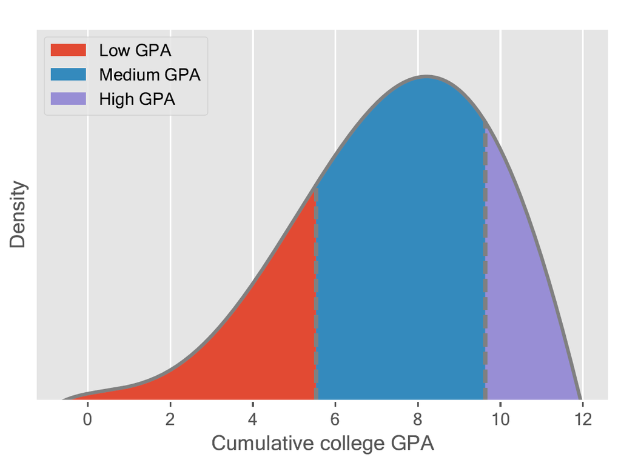

```python
display(Image('output/distribution_GPA_color.png',width=500))
```

To explore the robustness of this choice we assess the model performance under alternative variations of the target below. We focus the performance under different binnings of the target variable and limit our analysis to even bin sizes in terms of number of observations.

#### Logistic regresion, target: 3 even-sized bins

The first plot shows the main plot using 3 even- sized bins.

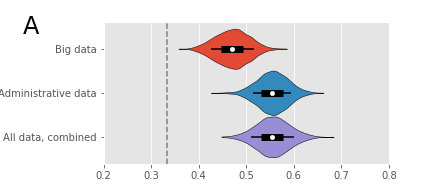

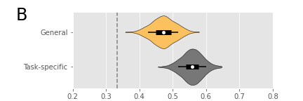

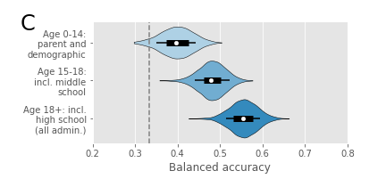

```python
display(Image('output/major_lr_p1_even3_letter.png'))
display(Image('output/task_lr_p1_even3_letter.png'))
display(Image('output/expanding_lr_p1_even3_letter.png'))
```

#### Logistic regresion, target: 4 even-sized bins

The first plot shows the main plot using 4 even- sized bins.

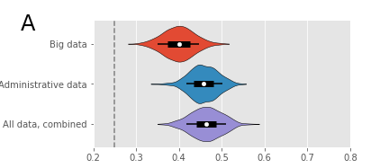

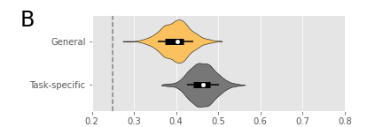

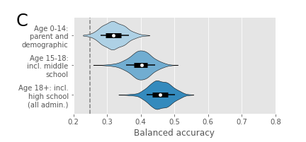

```python
display(Image('output/major_lr_p1_even4_letter.png'))
display(Image('output/task_lr_p1_even4_letter.png'))
display(Image('output/expanding_lr_p1_even4_letter.png'))
```

#### Statistical tests for comparison under different models

The table below replicate the statistical tests, including using alternative target definitions.

```python
pd.read_csv('output/comparison_tab_targets.csv',index_col=0,header=[0])
```

|  | Logistic Regression, polynom. order=1 | Log. regression, pol. ord.=1; 3 even bin target | Log. regression, pol. ord.=1; 4 even bin target |
| --- | --- | --- | --- |
| Administrative data vs Big data | -0.15 (p=0.0000) | -0.08 (p=0.0009) | -0.06 (p=0.0361) |
| Administrative data vs All data, combined | 0.00 (p=0.9104) | 0.00 (p=0.9640) | 0.01 (p=0.7774) |
| Age 0-14: parent and demographic vs Age 15-18: incl. middle school | 0.10 (p=0.0005) | 0.08 (p=0.0009) | 0.08 (p=0.0018) |
| Age 15-18: incl. middle school vs Administrative data | 0.12 (p=0.0005) | 0.07 (p=0.0006) | 0.06 (p=0.0199) |
| General vs Task-specific | 0.18 (p=0.0000) | 0.09 (p=0.0009) | 0.06 (p=0.0151) |

#### Comparison of balanced accuracy under different models

```python
pd.read_csv('output/acc_tab_targets.csv',index_col=0,header=[0,1])
```

| Model Feature set | Logistic Regression, polynom. order=1 Mean | Logistic Regression, polynom. order=1 Std. Dev. | Log. regression, pol. ord.=1; 3 even bin target Mean | Log. regression, pol. ord.=1; 3 even bin target Std. Dev. | Log. regression, pol. ord.=1; 4 even bin target Mean | Log. regression, pol. ord.=1; 4 even bin target Std. Dev. |
| --- | --- | --- | --- | --- | --- | --- |
| Big data | 0.426 | 0.034 | 0.470 | 0.035 | 0.399 | 0.036 |
| Administrative data | 0.576 | 0.045 | 0.555 | 0.033 | 0.457 | 0.033 |
| All data, combined | 0.579 | 0.047 | 0.556 | 0.035 | 0.463 | 0.037 |
| Age 0-14: parent and demographic | 0.364 | 0.021 | 0.397 | 0.037 | 0.320 | 0.034 |
| Age 15-18: incl. middle school | 0.460 | 0.046 | 0.481 | 0.032 | 0.399 | 0.035 |
| Task-specific | 0.601 | 0.048 | 0.558 | 0.032 | 0.462 | 0.031 |
| General | 0.418 | 0.037 | 0.472 | 0.035 | 0.400 | 0.034 |